# Assignment 2: MS5130 - Diary Writting

**Code -**

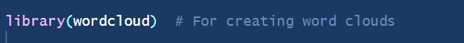

**Note**

**Diary entry date:** **24 March 2024**

**Problem Statement:** My task was to merge multiple datasets based on a common ‘City’ column using the **`inner_join`** function from the **`dplyr`** package in R. However, upon execution, I encountered an error indicating a missing argument. This issue was perplexing as it disrupted my workflow for data analysis, and I needed to solve it to progress with my assignment.

**Code -**

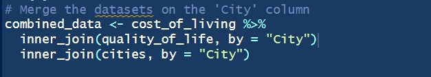

**Error -**

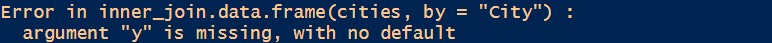

**Solution:** Initially, the code I used, sourced from educational material, was resulting in an error. Seeking a solution, I turned to [Stackoverflow](https://stackoverflow.com/questions/61219227/summarize-with-custom-function-while-calling-values-from-outside-of-group) and consulted ChatGPT, which led to the realization that I had omitted the **`%>%`**, the forward pipe operator, from the second line of my code. This operator is crucial as it passes the result of one function to the next in a sequence of operations. Correctly implementing the pipe operator allowed the code to execute as intended. The correct code is as

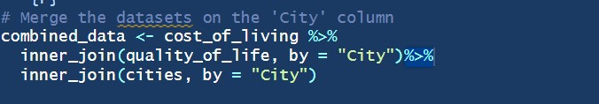

**Note**

**Diary entry date:** **03 April 2024**

**Problem Statement:** In the process of creating an interactive Leaflet map for visualizing the top 10 cities based on Movehub Rating in RStudio, I encountered an error that halted the rendering of my map. The error message stated: “Error: object ‘Esri.WorldTopoMap’ not found.” This suggested that the specified tile provider within the **`addProviderTiles()`** function could not be recognized by Leaflet, thus preventing the map from being displayed.

**Code -**

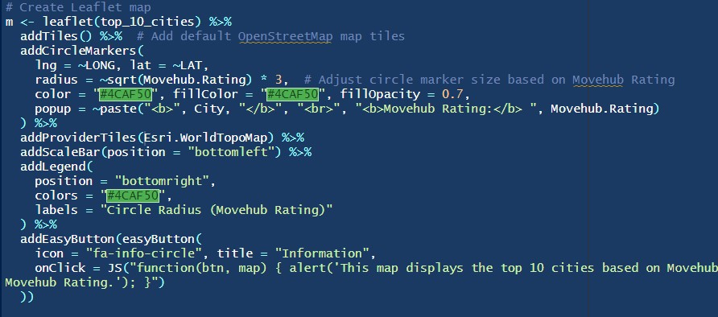

**Solution:** After encountering the error, I sought assistance from various resources like Github. The breakthrough came when I realized that the tile provider’s name needed to be correctly referenced within a list of providers. The solution involved correctly specifying the “providers” object in the **`addProviderTiles()`** function. The correct code is shown below, which facilitated the successful rendering of the map:

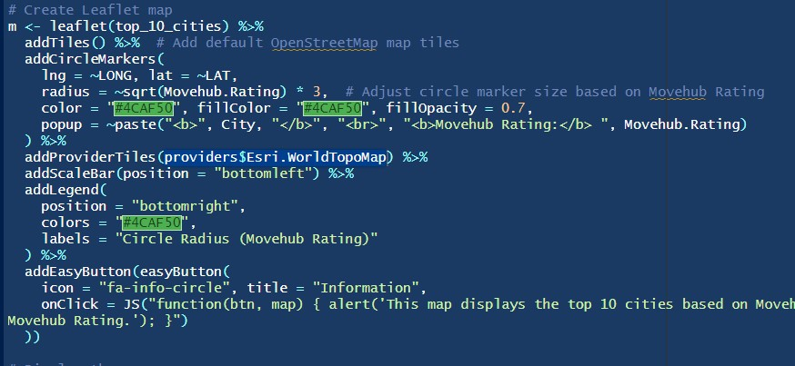

**Note**

**Diary entry date:** **03 April 2024**

**Problem Statement:** While working with a dataset in Assignment 2, I stumbled upon an issue where I couldn’t reference a column named “Quality of life” in my code. Attempts to use both “Quality of life” and “Quality_of_life” as the column name resulted in errors, suggesting that R did not recognize the column. Despite consulting various R programming resources and forums, the solution was not immediately clear, which hindered my data manipulation process.

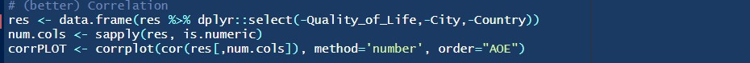

**Error -**

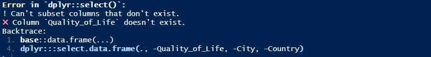

**Solution:** After numerous trials and further research, I discovered that the issue was due to R’s variable naming conventions and how certain packages interpret them. Specifically, when R imports data, it sometimes transforms spaces in column names into dots (.), depending on the function or package used for importing. This behavior is not consistently documented, leading to confusion. The resolution came when I altered my column reference to “Quality.of.life”, matching R’s internal representation of the column name. The correct snippet of code that addressed the issue was:

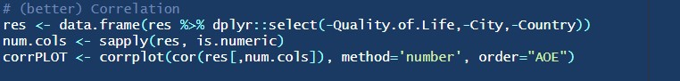